# Tugas 7

Salsabila Dwi Rahmi

2023-10-15

### Menyiapkan Packages

```r
library(ggplot2)
library(tsibble)
library(tseries)
library(MASS)
library(forecast)
library(TSA)
library(TTR)
library(aTSA)
library(graphics)
library(rio)
```

### Import Data

```r
data <- import("https://raw.githubusercontent.com/salsabiladwi/PRAKMPDW/main/Data/data1.csv")
head(data)
```

```
##         Date Close
## 1 2021-01-01  2600
## 2 2021-01-08  3180
## 3 2021-01-15  3090
## 4 2021-01-22  2380
## 5 2021-01-29  2400
## 6 2021-02-05  2870
```

```r
## Membuat set data menjadi data time series
data.ts <- ts(data$Close)
data.ts
```

```
## Time Series:
## Start = 1
## End = 139
## Frequency = 1
##   [1] 2600 3180 3090 2380 2400 2870 2780 2960 2520 2230 2290 2180 2240 2470 2320
##  [16] 2350 2510 2620 2670 2420 2390 2520 2420 2330 2250 2230 2550 2610 2570 2590
##  [31] 2370 2400 2270 2270 2320 2440 2410 2290 2290 2330 2420 2450 2320 2380 2370
##  [46] 2330 2440 2340 2330 2290 2240 2250 2230 1965 1935 1765 1840 1880 1945 2220
##  [61] 2290 2570 2350 2640 2440 2760 2780 2790 2600 2600 2330 2460 2490 2510 2400
##  [76] 2150 1965 1800 1720 1650 1675 2000 1970 2240 2050 1995 1935 1920 2070 2080
##  [91] 1920 1930 1830 1820 1840 1830 2000 1975 1970 2040 1990 1935 2030 2010 1965
## [106] 2130 2270 2320 2350 2220 2110 2030 2010 1875 1795 1885 2090 2100 2130 2100
## [121] 2080 2130 2040 1935 1945 1895 1985 2040 2010 1950 2020 1990 1990 1970 2010
## [136] 1990 1960 1995 1990
```

### Eksplorasi Data

#### Plot Data Penuh

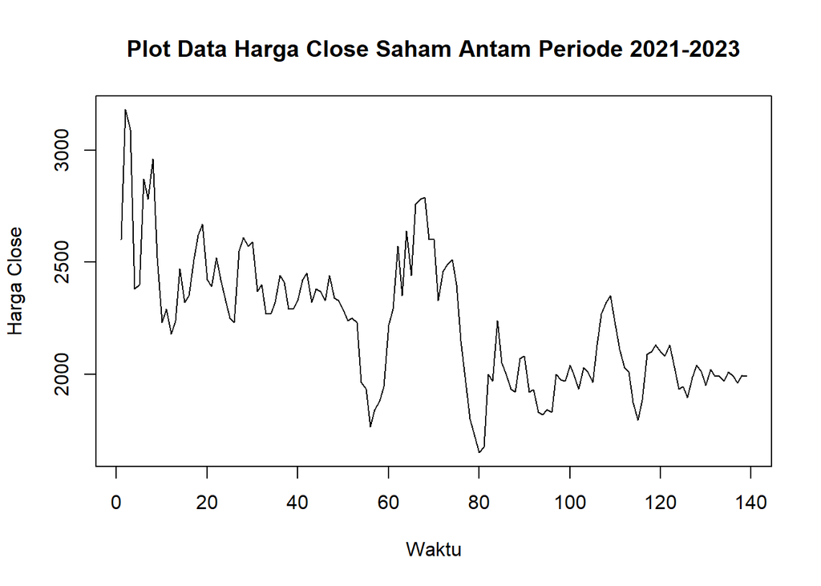

```r
plot.ts(data.ts, lty=1, xlab="Waktu", ylab="Harga Close", main="Plot Data Harga Close Saham Antam Periode 2021-2023")
```

Berdasarkan plot data deret waktu, terlihat bahwa data cenderung memiliki trend yang turun meski kerap kali bergerak pada suatu nilai tengah tertentu . Berdasarkan pola data, pembagian data latih dan data uji ditetapkan dengan proporsi 72% dan 28%.

#### Plot Data Latih

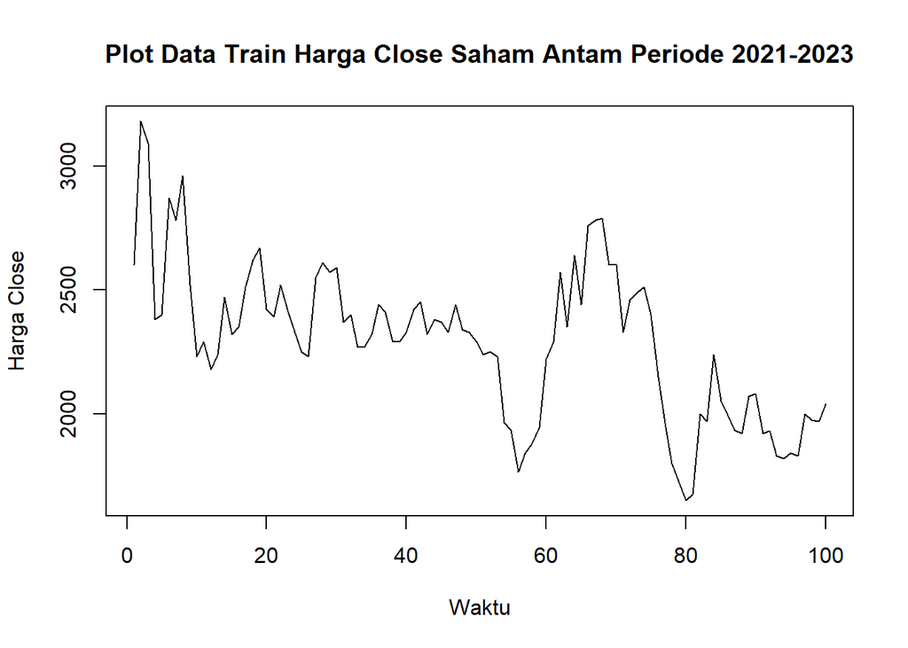

```r
datatrain<-data.ts[1:100]
train.ts<-ts(datatrain)
plot.ts(train.ts, lty=1, xlab="Waktu", ylab="Harga Close", main="Plot Data Train Harga Close Saham Antam Periode 2021-2023")
```

Berdasarkan plot data deret waktu pada data latih, terlihat bahwa data cenderung memilik trend turun. Hal ini mengindikasikan bahwa data tidak stasioner dalam rataan.

#### Plot Data Uji

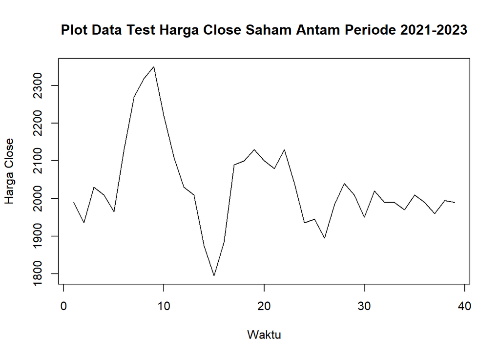

```r
datatest<-data.ts[101:139]
test.ts<-ts(datatest)
plot.ts(test.ts, lty=1, xlab="Waktu", ylab="Harga Close", main="Plot Data Test Harga Close Saham Antam Periode 2021-2023")
```

### Uji Stasioneritas Data

#### Plot ACF

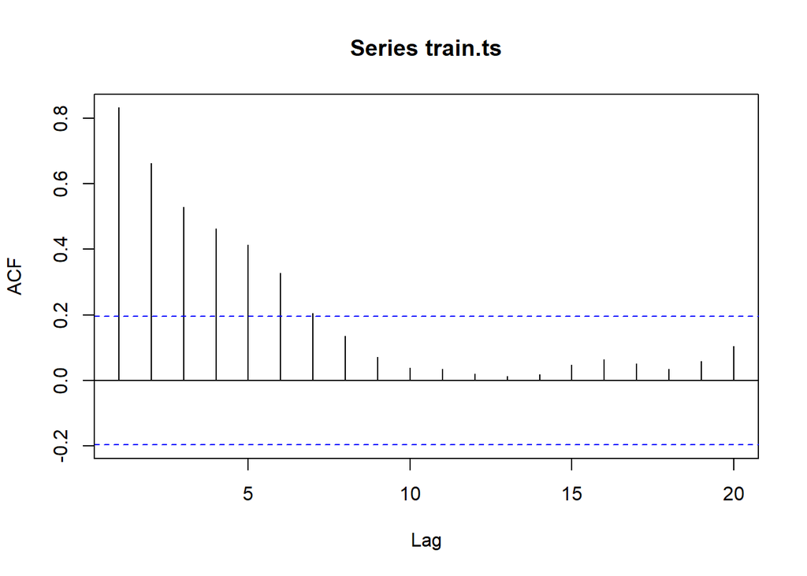

```r
acf(train.ts)
```

Berdasarkan plot ACF, terlihat bahwa plot ACF (*tails off slowly*). Hal ini juga menjadi indikasi bahwa data tidak stasioner dalam rataan.

#### Uji ADF

```r
tseries::adf.test(train.ts)
```

```
##
##  Augmented Dickey-Fuller Test
##
## data:  train.ts
## Dickey-Fuller = -2.9049, Lag order = 4, p-value = 0.2018
## alternative hypothesis: stationary
```

$H_0$ : Data tidak stasioner dalam rataan

$H_1$ : Data stasioner dalam rataan

Berdasarkan uji ADF tersebut, didapat *p-value* sebesar 0.2018 yang lebih besar dari taraf nyata 5% sehingga tak tolak $H_0$ dan menandakan bahwa data tidak stasioner dalam rataan. Hal ini sesuai dengan hasil eksplorasi menggunakan plot time series dan plot ACF, sehingga ketidakstasioneran model kedepannya harus ditangani.

#### Plot Box-Cox

```r
index <- seq(1:100)
bc = boxcox(train.ts~index, lambda = seq(5,10,by=1))
```

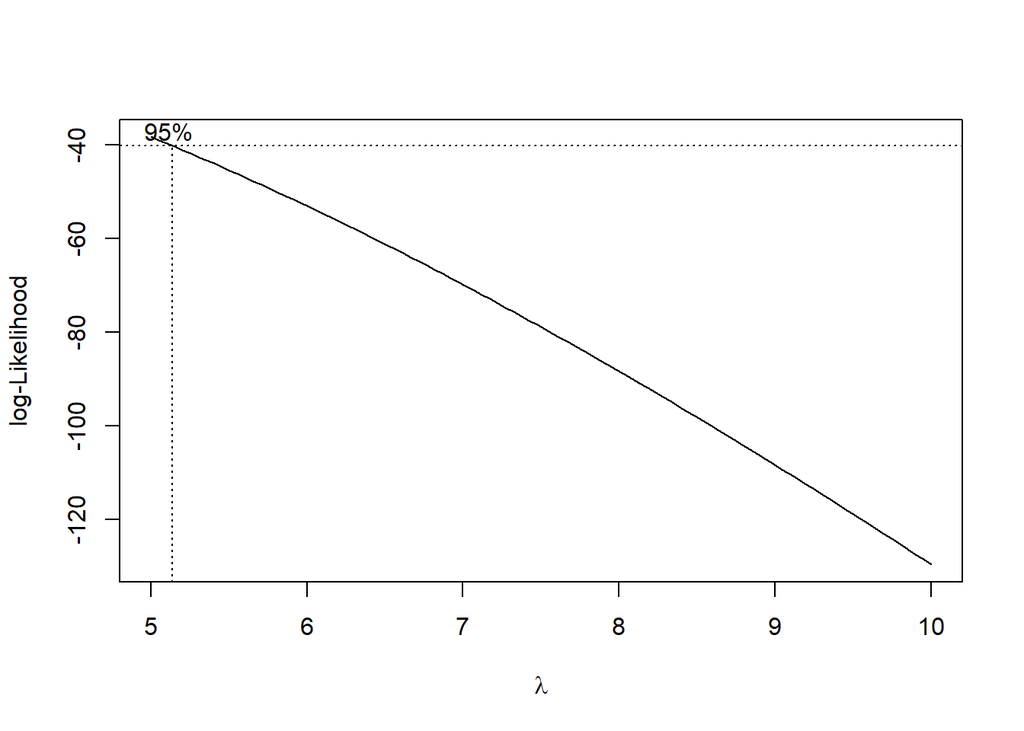

```r
#Nilai Rounded Lambda
lambda <- bc$x[which.max(bc$y)]
lambda
```

```
## [1] 5
```

```r
#SK
bc$x[bc$y > max(bc$y) - 1/2 * qchisq(.95,1)]
```

```
## [1] 5.000000 5.050505 5.101010
```

Plot Boxcox menunjukkan nilai *rounded value* ($\lambda$) optimum sebesar **5.00** dan pada selang kepercayaan 95% nilai memiliki batas bawah **5.00** dan batas atas **5.10**. Selang tersebut tidak memuat nilai satu sehingga dapat dikatakan bahwa data tidak stasioner dalam ragam.

### Penanganan Ketidakstasioneran Data

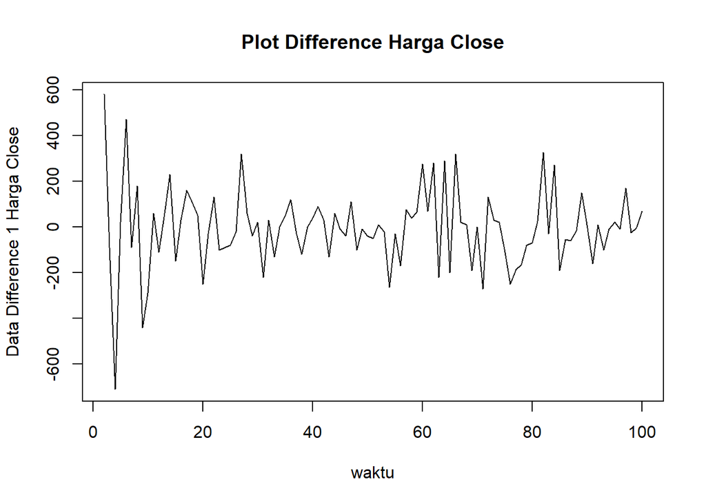

```r
train.diff<-diff(train.ts,differences = 1)
plot.ts(train.diff, lty=1, xlab="waktu", ylab="Data Difference 1 Harga Close", main="Plot Difference Harga Close")
```

#### Plot ACF

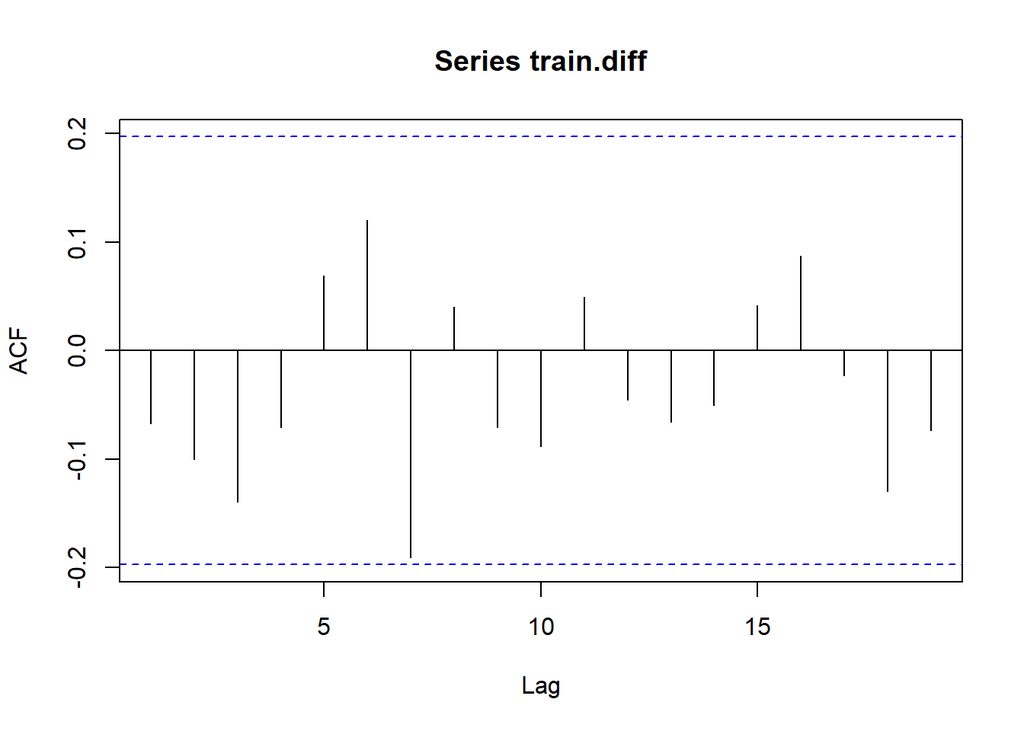

```r
acf(train.diff)
```

Berdasarkan plot tersebut, terlihat bahwa plot ACF cuts off. Hal ini menandakan data sudah stasioner dalam rataan dan ketidakstasioneran data telah berhasil tertangani.

#### Uji ADF

```r
tseries::adf.test(train.diff)
```

```
##
##  Augmented Dickey-Fuller Test
##
## data:  train.diff
## Dickey-Fuller = -5.0725, Lag order = 4, p-value = 0.01
## alternative hypothesis: stationary
```

$H_0$ : Data tidak stasioner dalam rataan

$H_1$ : Data stasioner dalam rataan

Berdasarkan uji ADF tersebut, didapat *p-value* sebesar 0.01 yang lebih kecil dari taraf nyata 5% sehingga tolak $H_0$ atau data stasioner dalam rataan. Hal ini sesuai dengan hasil eksplorasi menggunakan plot time series dan plot ACF, sehingga dalam hal ini ketidakstasioneran data sudah berhasil ditangani dan dapat dilanjutkan ke pemodelan

### Identifikasi Model

#### Plot ACF

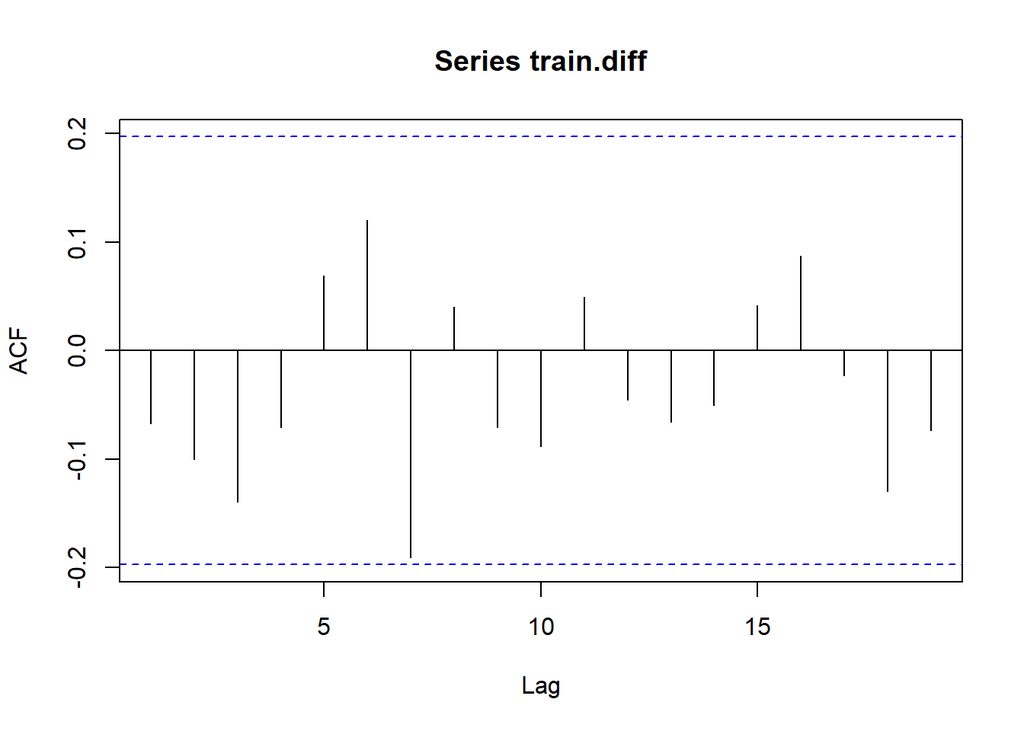

```r
acf(train.diff)
```

Berdasarkan plot tersebut, terlihat bahwa plot ACF cenderung *tails of*,tetapi masih sulit untuk melihat model tentatif dari plot ini.

#### Plot PACF

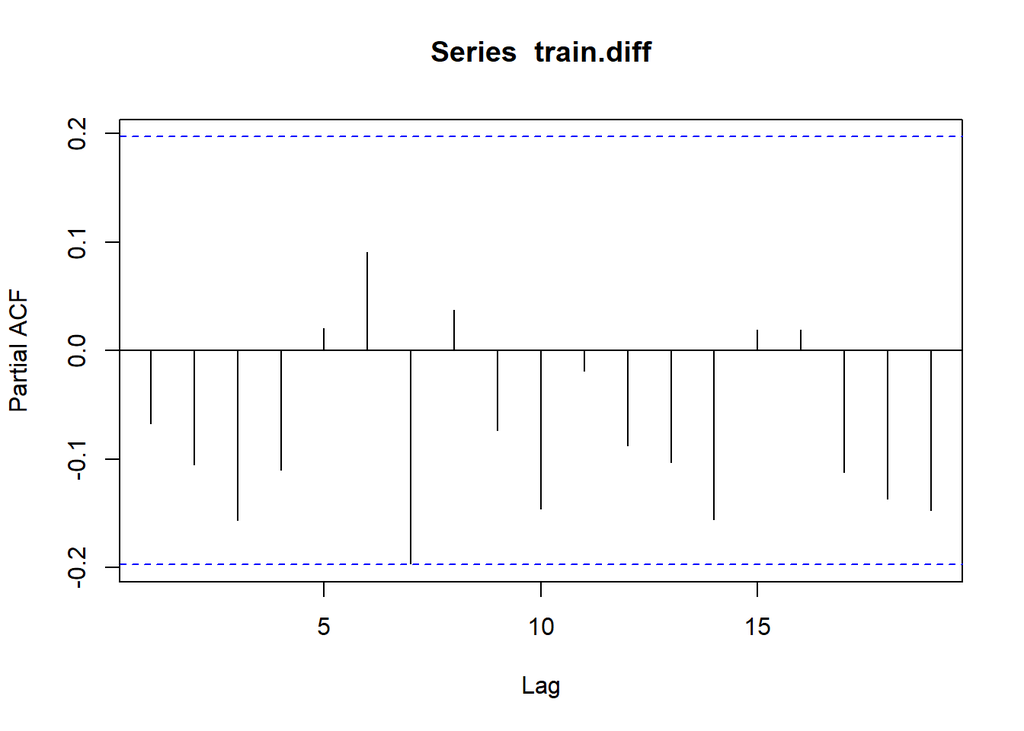

```r
pacf(train.diff)
```

#### Plot EACF

```r
eacf(train.diff)
```

```
## AR/MA
##   0 1 2 3 4 5 6 7 8 9 10 11 12 13
## 0 o o o o o o o o o o o  o  o  o
## 1 x o o o o o o o o o o  o  o  o
## 2 x x o o o o o o o o o  o  o  o
## 3 x x o o o o o o o o o  o  o  o
## 4 x x x x o o o o o o o  o  o  o
## 5 x x o x o o o o o o o  o  o  o
## 6 x x o o o o o o o o o  o  o  o
## 7 o o x o o o o o o o o  o  o  o
```

Identifikasi model menggunakan plot EACF dilakukan dengan melihat ujung segitiga pada pola segitiga nol. Dalam hal ini model tentatif yang terbentuk adalah ARIMA(0,1,1) ARIMA(0,1,2), ARIMA(1,1,1), ARIMA(1,1,2) dan ARIMA(2,1,2).

### Pendugaan Parameter Model Tentatif

#### ARIMA(0,1,1)

```r
model1.da=Arima(train.diff, order=c(0,1,1),method="ML")
summary(model1.da) #AIC=1299.9
```

```
## Series: train.diff
## ARIMA(0,1,1)
##
## Coefficients:
##           ma1
##       -1.0000
## s.e.   0.0263
##
## sigma^2 = 31224:  log likelihood = -647.95
## AIC=1299.9   AICc=1300.02   BIC=1305.07
##
## Training set error measures:
##                     ME     RMSE      MAE MPE MAPE      MASE       ACF1
## Training set -9.425763 174.9079 119.9653 NaN  Inf 0.6358358 0.03995639
```

```r
lmtest::coeftest(model1.da) #semua parameter signifikan
```

```
##
## z test of coefficients:
##
##      Estimate Std. Error z value  Pr(>|z|)
## ma1 -0.999983   0.026349 -37.951 < 2.2e-16 ***
## ---
## Signif. codes:  0 '***' 0.001 '**' 0.01 '*' 0.05 '.' 0.1 ' ' 1
```

#### ARIMA(0,1,2)

```r
model2.da=Arima(train.diff, order=c(0,1,2),method="ML")
summary(model2.da) #AIC= 1301.43
```

```
## Series: train.diff
## ARIMA(0,1,2)
##
## Coefficients:
##           ma1     ma2
##       -1.0851  0.0852
## s.e.   0.1285  0.1257
##
## sigma^2 = 31339:  log likelihood = -647.71
## AIC=1301.43   AICc=1301.68   BIC=1309.18
##
## Training set error measures:
##                     ME    RMSE      MAE MPE MAPE      MASE      ACF1
## Training set -7.868724 174.325 119.3316 NaN  Inf 0.6324768 0.1144604
```

```r
lmtest::coeftest(model2.da) #tidak semua parameter signifikan
```

```
##
## z test of coefficients:
##
##      Estimate Std. Error z value Pr(>|z|)
## ma1 -1.085143   0.128512 -8.4439   <2e-16 ***
## ma2  0.085152   0.125724  0.6773   0.4982
## ---
## Signif. codes:  0 '***' 0.001 '**' 0.01 '*' 0.05 '.' 0.1 ' ' 1
```

#### ARIMA(1,1,1)

```r
model3.da=Arima(train.diff, order=c(1,1,1),method="ML")
summary(model3.da) #AIC=1301.54
```

```
## Series: train.diff
## ARIMA(1,1,1)
##
## Coefficients:
##           ar1      ma1
##       -0.0644  -1.0000
## s.e.   0.1071   0.0266
##
## sigma^2 = 31392:  log likelihood = -647.77
## AIC=1301.54   AICc=1301.79   BIC=1309.29
##
## Training set error measures:
##                     ME    RMSE      MAE MPE MAPE      MASE       ACF1
## Training set -8.340104 174.472 119.3159 NaN  Inf 0.6323936 0.09743376
```

```r
lmtest::coeftest(model3.da) #tidak semua parameter signifikan
```

```
##
## z test of coefficients:
##
##      Estimate Std. Error  z value Pr(>|z|)
## ar1 -0.064375   0.107138  -0.6009   0.5479
## ma1 -0.999999   0.026590 -37.6076   <2e-16 ***
## ---
## Signif. codes:  0 '***' 0.001 '**' 0.01 '*' 0.05 '.' 0.1 ' ' 1
```

#### ARIMA(1,1,2)

```r
model4.da=Arima(train.diff, order=c(1,1,2),method="ML")
summary(model4.da) #AIC=1296.46
```

```
## Series: train.diff
## ARIMA(1,1,2)
##
## Coefficients:
##          ar1      ma1     ma2
##       0.7785  -1.9987  0.9999
## s.e.  0.0746   0.0573  0.0573
##
## sigma^2 = 28085:  log likelihood = -644.23
## AIC=1296.46   AICc=1296.89   BIC=1306.8
##
## Training set error measures:
##                     ME     RMSE      MAE MPE MAPE      MASE      ACF1
## Training set -5.272561 164.1646 117.2555 NaN  Inf 0.6214734 0.1300964
```

```r
lmtest::coeftest(model4.da) #semua parameter signifikan
```

```
##
## z test of coefficients:
##
##      Estimate Std. Error z value  Pr(>|z|)
## ar1  0.778526   0.074586  10.438 < 2.2e-16 ***
## ma1 -1.998662   0.057344 -34.854 < 2.2e-16 ***
## ma2  0.999868   0.057346  17.436 < 2.2e-16 ***
## ---
## Signif. codes:  0 '***' 0.001 '**' 0.01 '*' 0.05 '.' 0.1 ' ' 1
```

#### ARIMA(2,1,2)

```r
model5.da=Arima(train.diff, order=c(2,1,2),method="ML")
summary(model5.da) #AIC=1298.17
```

```
## Series: train.diff
## ARIMA(2,1,2)
##
## Coefficients:
##          ar1      ar2      ma1     ma2
##       0.8211  -0.0586  -1.9983  0.9994
## s.e.  0.1076   0.1082   0.0603  0.0603
##
## sigma^2 = 28235:  log likelihood = -644.08
## AIC=1298.17   AICc=1298.82   BIC=1311.09
##
## Training set error measures:
##                     ME     RMSE      MAE MPE MAPE      MASE       ACF1
## Training set -6.283518 163.7336 117.9529 Inf  Inf 0.6251695 0.08268015
```

```r
lmtest::coeftest(model5.da) #tidak semua parameter signifikan
```

```
##
## z test of coefficients:
##
##      Estimate Std. Error  z value  Pr(>|z|)
## ar1  0.821106   0.107552   7.6345 2.267e-14 ***
## ar2 -0.058563   0.108233  -0.5411    0.5885
## ma1 -1.998251   0.060339 -33.1173 < 2.2e-16 ***
## ma2  0.999434   0.060341  16.5630 < 2.2e-16 ***
## ---
## Signif. codes:  0 '***' 0.001 '**' 0.01 '*' 0.05 '.' 0.1 ' ' 1
```

Berdasarkan pendugaan parameter di atas, nilai AIC terkecil dimiliki oleh model ARIMA(1,1,2) selain itu juga semua parameternya signifikan sehingga model yang dipilih adalah model ARIMA(1,1,2).

### Analisis Sisaan

Model terbaik hasil identifikasi kemudian dicek asumsi sisaannya. Sisaan model ARIMA harus memenuhi asumsi normalitas, kebebasan sisaan, dan kehomogenan ragam. Diagnostik model dilakukan secara eksplorasi dan uji formal.

#### Eksplorasi Sisaan

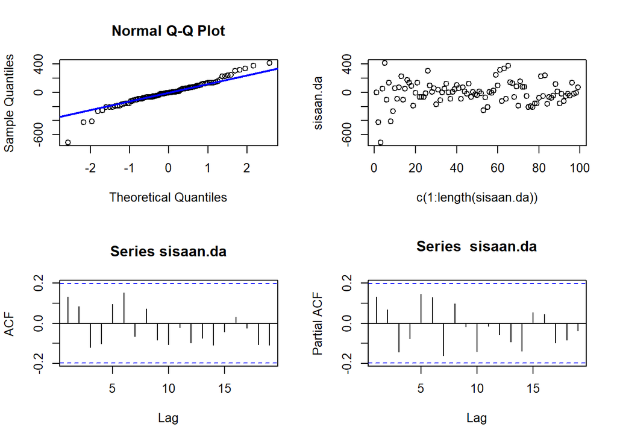

```r
#Eksplorasi
sisaan.da <- model4.da$residuals
par(mfrow=c(2,2))
qqnorm(sisaan.da)
qqline(sisaan.da, col = "blue", lwd = 2)
plot(c(1:length(sisaan.da)),sisaan.da)
acf(sisaan.da)
pacf(sisaan.da)
```

```r
par(mfrow = c(1,1))
```

Berdasarkan plot kuantil-kuantil normal, secara eksplorasi ditunjukkan sisaan tidak menyebar normal ditandai dengan titik titik yang cenderung tidak mengikuti garis $45^{\circ}$. Kemudian dapat dilihat juga lebar pita sisaan yang cenderung sama menandakan bahwa sisaan memiliki ragam yang homogen. Plot ACF dan PACF sisaan ARIMA(1,1,2) juga tidak signifikan pada 20 lag awal yang menandakan saling bebas. Kondisi ini akan diuji lebih lanjut dengan uji formal.

#### Uji Formal

```r
#1) Sisaan Menyebar Normal
ks.test(sisaan.da,"pnorm")  #tak tolak H0 > sisaan menyebar normal
```

```
##
##  Exact one-sample Kolmogorov-Smirnov test
##
## data:  sisaan.da
## D = 0.50505, p-value = 1.998e-15
## alternative hypothesis: two-sided
```

Selain dengan eksplorasi, asumsi tersebut dapat diuji menggunakan uji formal. Pada tahapan ini uji formal yang digunakan untuk normalitas adalah uji Kolmogorov-Smirnov (KS). Hipotesis pada uji KS adalah sebagai berikut.

$H_0$ : Sisaan menyebar normal

$H_1$ : Sisaan tidak menyebar normal

Berdasarkan uji KS tersebut, didapat *p-value* sebesar 1.998e-15 yang kurang dari taraf nyata 5% sehingga tolak $H_0$ dan menandakan bahwa sisaan tidak menyebar normal. Hal ini sesuai dengan hasil eksplorasi menggunakan plot kuantil-kuantil normal.

```r
#2) Sisaan saling bebas/tidak ada autokorelasi
Box.test(sisaan.da, type = "Ljung")  #tak tolak H0 > sisaan saling bebas
```

```
##
##  Box-Ljung test
##
## data:  sisaan.da
## X-squared = 1.7269, df = 1, p-value = 0.1888
```

Selanjutnya akan dilakukan uji formal untuk kebebasan sisaan menggunakan uji Ljung-Box. Hipotesis yang digunakan adalah sebagai berikut.

$H_0$ : Sisaan saling bebas

$H_1$ : Sisaan tidak tidak saling bebas

Berdasarkan uji Ljung-Box tersebut, didapat *p-value* sebesar 0.1888 yang lebih besar dari taraf nyata 5% sehingga tak tolak $H_0$ dan menandakan bahwa sisaan saling bebas. Hal ini sama dengan eksplorasi.

```r
#3) Sisaan homogen
Box.test((sisaan.da)^2, type = "Ljung")  #tak tolak H0 > sisaan homogen
```

```
##
##  Box-Ljung test
##
## data:  (sisaan.da)^2
## X-squared = 2.7987, df = 1, p-value = 0.09434
```

Hipotesis yang digunakan untuk uji kehomogenan ragam adalah sebagai berikut.

$H_0$ : Ragam sisaan homogen

$H_1$ : Ragam sisaan tidak homogen

Berdasarkan uji Ljung-Box terhadap sisaan kuadrat tersebut, didapat *p-value* sebesar 0.09434 yang lebih dari taraf nyata 5% sehingga tak tolak $H_0$ dan menandakan bahwa ragam sisaan homogen.

```r
#4) Nilai tengah sisaan sama dengan nol
t.test(sisaan.da, mu = 0, conf.level = 0.95)
```

```
##
##  One Sample t-test
##
## data:  sisaan.da
## t = -0.31811, df = 98, p-value = 0.7511
## alternative hypothesis: true mean is not equal to 0
## 95 percent confidence interval:
##  -38.16426  27.61914
## sample estimates:
## mean of x
## -5.272561
```

```r
#tak tolak h0 > nilai tengah sisaan sama dengan 0
```

Terakhir, dengan uji-t, akan dicek apakah nilai tengah sisaan sama dengan nol. Hipotesis yang diujikan sebagai berikut.

$H_0$ : nilai tengah sisaan sama dengan 0

$H_1$ : nilai tengah sisaan tidak sama dengan 0

Berdasarkan uji-ttersebut, didapat *p-value* sebesar 0.7511 yang lebih besar dari taraf nyata 5% sehingga tak tolak $H_0$ dan menandakan bahwa nilai tengah sisaan sama dengan nol.

### Overfitting

Tahapan selanjutnya adalah *overfitting* dilakukan dengan menaikkan orde AR(p) dan MA(q) dari model ARIMA(1,1,2) untuk melihat apakah terdapat model lain yang lebih baik dari model saat ini. Kandidat model *overfitting* adalah ARIMA(2,1,2) dan ARIMA(1,1,3).

```r
model4a.da=Arima(train.diff, order=c(2,1,2),method="ML")
summary(model4a.da) #AIC=1298.17
```

```
## Series: train.diff
## ARIMA(2,1,2)
##
## Coefficients:
##          ar1      ar2      ma1     ma2
##       0.8211  -0.0586  -1.9983  0.9994
## s.e.  0.1076   0.1082   0.0603  0.0603
##
## sigma^2 = 28235:  log likelihood = -644.08
## AIC=1298.17   AICc=1298.82   BIC=1311.09
##
## Training set error measures:
##                     ME     RMSE      MAE MPE MAPE      MASE       ACF1
## Training set -6.283518 163.7336 117.9529 Inf  Inf 0.6251695 0.08268015
```

```r
lmtest::coeftest(model4a.da) #tidak semua parameter signifikan
```

```
##
## z test of coefficients:
##
##      Estimate Std. Error  z value  Pr(>|z|)
## ar1  0.821106   0.107552   7.6345 2.267e-14 ***
## ar2 -0.058563   0.108233  -0.5411    0.5885
## ma1 -1.998251   0.060339 -33.1173 < 2.2e-16 ***
## ma2  0.999434   0.060341  16.5630 < 2.2e-16 ***
## ---
## Signif. codes:  0 '***' 0.001 '**' 0.01 '*' 0.05 '.' 0.1 ' ' 1
```

```r
model4b.da=Arima(train.diff, order=c(1,1,3),method="ML")
summary(model4b.da) #AIC=1298.27
```

```
## Series: train.diff
## ARIMA(1,1,3)
##
## Coefficients:
##          ar1      ma1     ma2     ma3
##       0.7766  -1.9480  0.9010  0.0483
## s.e.  0.1020   0.1453  0.2738  0.1339
##
## sigma^2 = 28433:  log likelihood = -644.14
## AIC=1298.27   AICc=1298.92   BIC=1311.2
##
## Training set error measures:
##                    ME     RMSE      MAE MPE MAPE      MASE       ACF1
## Training set -6.42769 164.3076 117.6635 Inf  Inf 0.6236355 0.08503222
```

```r
lmtest::coeftest(model4b.da) #tidak semua parameter signifikan
```

```
##
## z test of coefficients:
##
##      Estimate Std. Error  z value  Pr(>|z|)
## ar1  0.776580   0.102017   7.6123 2.694e-14 ***
## ma1 -1.948008   0.145305 -13.4063 < 2.2e-16 ***
## ma2  0.901040   0.273801   3.2909 0.0009988 ***
## ma3  0.048312   0.133941   0.3607 0.7183256
## ---
## Signif. codes:  0 '***' 0.001 '**' 0.01 '*' 0.05 '.' 0.1 ' ' 1
```

```r
#model yang dipilih adalah model awal, yaitu ARIMA(1,1,2)
```

Berdasarkan kedua model hasil *overfitting* di atas, model ARIMA(2,1,2) dan ARIMA(1,1,3) memiliki AIC yang lebih besar dibandingkan dengan model ARIMA(1,1,2) dan parameter kedua model ARIMA(2,1,2) dan ARIMA(1,1,3) tidak seluruhnya signifikan. Oleh karena itu, model ARIMA(1,1,2) akan tetap digunakan untuk melakukan peramalan.

### Peramalan

```r
#---FORECAST---#
ramalan <- forecast::forecast(model4.da, h = 39)
ramalan
```

```
##     Point Forecast     Lo 80    Hi 80     Lo 95    Hi 95
## 101     -15.623313 -232.1774 200.9307 -346.8142 315.5675
## 102     -13.697706 -234.6807 207.2853 -351.6621 324.2667
## 103     -12.198571 -235.7827 211.3855 -354.1409 329.7438
## 104     -11.031455 -236.1462 214.0833 -355.3148 333.2519
## 105     -10.122825 -236.1364 215.8908 -355.7808 335.5351
## 106      -9.415433 -235.9537 217.1229 -355.8759 337.0450
## 107      -8.864710 -235.7065 217.9771 -355.7893 338.0598
## 108      -8.435958 -235.4509 218.5789 -355.6253 338.7534
## 109      -8.102164 -235.2139 219.0096 -355.4396 339.2353
## 110      -7.842296 -235.0068 219.3222 -355.2604 339.5758
## 111      -7.639982 -234.8321 219.5521 -355.1003 339.8203
## 112      -7.482475 -234.6881 219.7232 -354.9635 339.9986
## 113      -7.359852 -234.5715 219.8518 -354.8501 340.1304
## 114      -7.264387 -234.4783 219.9495 -354.7581 340.2293
```

[output cut: 25 more lines]

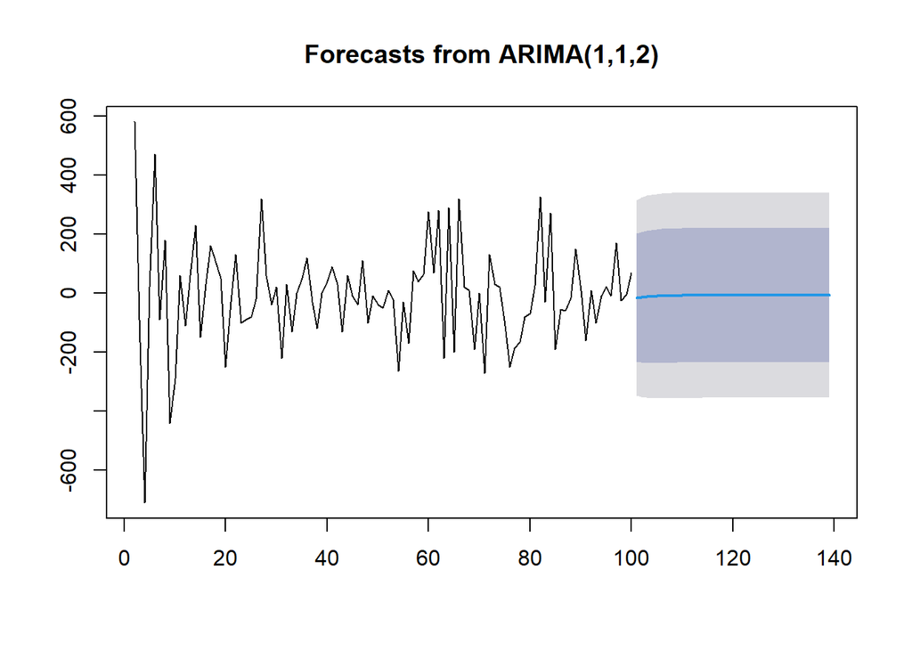

```r
data.ramalan <- ramalan$mean
plot(ramalan)
```

Berdasarkan hasil plot ramalan di atas, dapat dilihat bahwa ramalan ARIMA(1,1,2) cenderung stabil hingga akhir periode. Selanjutnya, dapat dicari nilai akurasi antara hasil ramalan dengan data uji sebagai berikut.

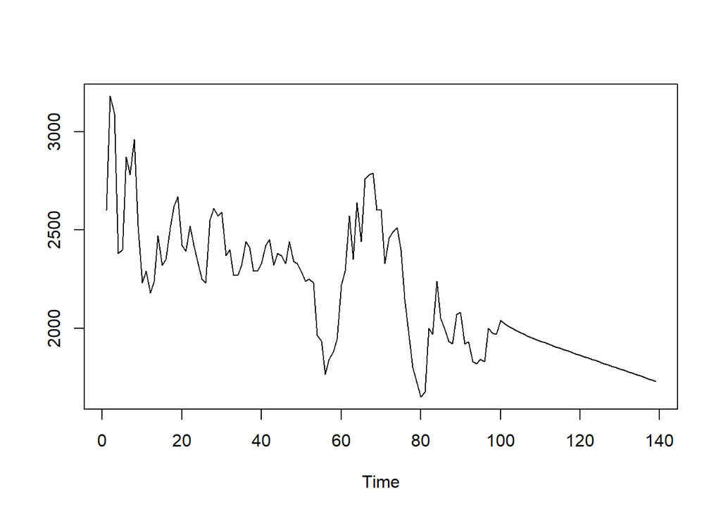

```r
pt_1 <- train.ts[100] #nilai akhir data latih
hasil.forc.Diff <- data.ramalan
hasil <- diffinv(hasil.forc.Diff, differences = 1) + pt_1
#has.1 sama hasilnta dengan: cumsum(c(pt_1,hasil.forc.Diff))
ts.plot(train.ts,hasil)
```

```r
perbandingan.da<-matrix(data=c(head(test.ts, n=39), hasil[-1]),
                     nrow = 39, ncol = 2)
colnames(perbandingan.da)<-c("Aktual","Hasil Forecast")
perbandingan.da
```

```
##       Aktual Hasil Forecast
##  [1,]   1990       2024.377
##  [2,]   1935       2010.679
##  [3,]   2030       1998.480
##  [4,]   2010       1987.449
##  [5,]   1965       1977.326
##  [6,]   2130       1967.911
##  [7,]   2270       1959.046
##  [8,]   2320       1950.610
##  [9,]   2350       1942.508
## [10,]   2220       1934.666
## [11,]   2110       1927.026
## [12,]   2030       1919.543
## [13,]   2010       1912.183
## [14,]   1875       1904.919
```

[output cut: 25 more lines]

```r
accuracy(ts(hasil[-1]), head(test.ts, n=39))
```

```
##                ME     RMSE      MAE      MPE     MAPE      ACF1 Theil's U
## Test set 166.8595 205.0273 180.2249 7.993325 8.705194 0.7470584  2.583551
```